# Incentives for Public Goods Inside Organizations: Field Experimental Evidence

Andrea Blasco

Olivia S. Jung

Karim R. Lakhani

Michael Menietti

Last updated: 22 August, 2017

Abstract

We report results of a natural field experiment conducted at a medical organization that sought contribution of public goods (i.e., projects for organizational improvement) from its 1200 employees. Offering a prize for winning submissions boosted participation by 85 percent without affecting the quality of the submissions. The effect was consistent across gender and job type. We posit that the allure of a prize, in combination with mission-oriented preferences, drove participation. Using a simple model, we estimate that these preferences explain about a third of the magnitude of the effect. We also find that these results were sensitive to the solicited person’s gender.

# Introduction

Employees divide their time between production tasks tied to pay and promotion and organizational improvements without explicit compensation. This dilemma leads to two key issues in the analysis of incentives inside organizations. First, compensation schemes need to address a multitasking problem [@holmstrom1991multitask; @hellmann2011incentives; @manso2011motivating] as time and effort are more likely to be directed towards the rewarded tasks. Second, the non-rival nature of improvement work that benefits the organization as a whole may tempt workers to free-ride on the efforts of others.

An organizational contest that seeks contribution of public goods (e.g., suggestion of organizational improvement opportunities) and offers a winning prize may be a proper way to remedy the incentives. Contests stimulate risk taking and participation in less-easily contractible tasks, as discussed by @lazear1981rank; @green1983comparison; @mary1984economic among others. However, traditional contest literature does not take into account the non-rival nature of contributing which constitutes the public good problem. Standard contest theory models presumes that only the contest sponsors (e.g., managers) enjoy the contest outcome, with small gains for the participants beyond the prizes given to the winners.[^1] This assumption may become questionable when contest participants can expect gains from the work of others, as in the case of a competition aiming at organizational improvements. These circumstances raise an important question: Are contests an effective incentive mechanism in fostering contributions to public goods inside organizations?

In the present study, we report results of a natural field experiment that considers two dominant perspectives on the issue. The first comes from the seminal work of @morgan2000financing, who stresses that awarding prizes in lottery-like contests will mitigate, or even eliminate, the incentive to free ride. At the margin, employees choose their level of effort so that expected gains and costs are equal. Because these gains include direct utility from receiving a prize and from improving their organization, employees’ participation is likely to be boosted beyond the pecuniary value of the prize. In the second perspective, employees will volunteer their effort when the contest aim matches the preferences of workers, as discussed by @besley2005competition, @prendergast2007motivation, @delfgaauw2008incentives among others.[^2] According to this perspective, announcing a competition for prizes can cause unintentional adverse consequences, such as evoking mixed behaviors in workers with varying inclinations towards competition or risk [e.g., men and women @niederle2007women; @croson2009gender]; promoting unethical behavior [@lazear1989pay; @charness2013dark]; weakening intrinsic motivations [@reeve1996elements; @frey1997not]; and even hurting the creativity of innovative work [@erat2015incentives].

We conducted this study in collaboration with the Massachusetts General Hospital’s (MGH) Corrigan Minehan Heart Center (“Heart Center”), a prominent medical organization in the United States and a teaching hospital of the Harvard Medical School. The health care delivery context is particularly relevant as the need for organizational improvement and innovation is vastly noted [e.g., @cutler2012reducing]. In addition, health care professionals are commonly seen as willing to step beyond the boundaries of their contractual duties to offer better care [@delfgaauw2005dedicated], which makes the comparison of different incentives towards a public good especially relevant and interesting.

The Heart Center launched a contest aimed to improve the operations of the organization, in the spirit of “open innovation” discussed in @terwiesch2008innovation, @lakhani2013prize, and @glaeser2016predictive. The contest solicited employees to submit project proposals describing an existing problem and providing a solution to address the problem. After the submission phase, the contest invited all employees to read and rate each proposal on a five-point scale. The winning proposal would receive funding for implementation, implying additional costs and responsibilities from making a winning proposal, such as providing further guidance or a direct involvement in implementation, that were not compensated by winning the competition. Winners of the contest received an iPad mini, the value of which was relatively small in comparison to the foreseeable costs of unpaid proposal implementation time and effort.

The subject pool consisted of over 1,200 staff members of the Heart Center including physicians, nurses, and administrative staff (the entire population). Our main intervention involved altering the content of solicitation: in the PRIZE treatment, the solicitation nudged employees to participate to win an iPad mini; in the FUND treatment, the solicitation nudged employees to participate to win $20,000 towards implementation of the proposal (the submitters would not receive this money for personal use); in the remaining two treatments, we emphasized the opportunity to improve the health care of the patients (PCARE) or the workplace (WPLACE). We randomly assigned each Heart Center staff to receive one of the four solicitations.

By doing so, we obtained causal estimates of the effect of different incentives on two main outcomes: (a) the decision to submit a proposal and engage in an organizational improvement task and (b) the quality of the submissions measured by over 12,000 peer ratings and about 100 evaluations made by the contest organizers. Using data on profession and gender, we also characterized the heterogeneity of responses to the treatment, testing the implications of our intervention for the organization.

We find a high participation rate despite its cost: 196 employees (16 percent) across the entire organization participated in the initiative, with 5 percent of our sample submitting a proposal.[^3] About half of the participants were invited to submit detailed implementation plans. Two of these submissions received funding for implementation.

Analysis of the peer ratings indicates that there was no crowding-out effect. The higher propensity of participation for employees in the PRIZE treatment does not seem to be driven by low-quality submissions. This result is consistent with ratings by the Heart Center managers. We also find small differences in content in terms of the number of proposals submitted by a participant, areas of focus, and proposal length across treatment groups. Overall, these findings suggest no trade-off between quantity and quality; treatments that attracted more participation resulted in proposals of comparable quality and content. This also implies that monetary incentives were not counter-productive to creativity compared to voluntary contributions.

We find that framing around the mission of the organization resulted in responses that were sensitive to the gender of the solicited person. Women’s participation was greater when emphasizing the patient care whereas men’s participation was significantly lower, controlling for the profession. At the same time, we do not find gender-based differences with respect to participation in the PRIZE treatment: women’s participation was slightly higher but not significant than men’s. The first finding suggests that gender may influence sensitivity to framing concerning the organizational mission (i.e., patient care). The second evidence indicates that gender differences in preferences, such as competitive inclinations or risk aversion, may not exert great influence on responses of workers to contests inside organizations.

Finally, employees were less likely to participate when solicited with the funding opportunity alone – even with a non-trivial amount of $20,000 in implementation funding – compared to all other treatments. This finding suggests that the opportunity to lead implementation of one’s own submitted idea, a non-production task, was not perceived as a reward.

# Literature

The present study contributes to the literature on the use of prizes (relative incentives) in the workplace [@lazear1981rank; @green1983comparison; @mary1984economic, among others]. Our main contribution consists in studying the role of prizes in fostering workers’ participation in the field and in activities that produce organizational improvements. In particular, the observed increase in participation in the PRIZE treatment is consistent with the results of existing empirical studies [@bull1987tournaments; @knoeber1994testing; @eriksson1999executive; @ehrenberg1990tournaments; @terwiesch2008innovation; @terwiesch2009innovation; @boudreau2011incentives; @boudreau2016performance]. However, while most studies focus on tournaments that result in benefits enjoyed exclusively by the sponsor of the competition (increasing sales, production, revenues), we show that this positive result generalizes to situations that generate positive externalities for the contestants (innovation projects to improve the organization). Despite being a common situation,[^4] this setting has received relatively less attention in past studies.

Our work also contributes to the empirical literature on the use of contest-type lotteries to finance public goods that was first studied by @morgan2000financing. A number of works have shown a positive effect of prizes on the extent of individual contributions to a public good in the laboratory [@morgan2000funding; @dale2004charitable; @lange2007using] and in the field [@landry2006toward]. However, as noted by @vesterlund2012voluntary, the existing evidence on the profitability of contest-type mechanisms for raising money for public goods (e.g., charity donations) is only mixed. Our work provides further evidence to this theory as we extend the results of past studies to an organizational setting. Within this setting, individual contributions are non-monetary but consist of time and effort in putting forward (and implementing) a proposal, and the public good consists of the potential improvements for the organization. Under such circumstances, we find evidence indicating that offering prizes can effectively raise the level of participation (compared to voluntary mechanisms) and overall appear to be a profitable solution for organizations.

Our results also relate to the literature on social preferences at work. A number of studies have shown that people tend to contribute to public goods despite strong incentives to free ride. According to the World Health Organization, about 60 percent of blood donations collected globally each year is from voluntary unpaid blood donors. According to @list2011market, charitable gifts of money are worth two percent of gross domestic product for the United States. @lacetera2014rewarding stresses that: “27% of Americans volunteer with formal organizations, for a total of about 8 billion hours per year.” A sizable scientific evidence on this topic comes from a series of studies based on economic games in the laboratory [see @levitt2007laboratory for a review] and in the field [@bandiera2005social; @dellavigna2016estimating]. @bandiera2005social, for instance, shows that workers internalize preferences of co-workers and may reduce effort under relative incentives. Likewise, @dellavigna2016estimating shows a positive effect of mission-oriented preferences, also called “vertical social preferences,”[^5] on the level of effort of free-lance workers folding envelopes for a charity. Our work is consistent with a positive effect of vertical social preferences; adding evidence that such social preferences not only increase effort in mandatory pre-specified tasks but also affect voluntary participation to non-mandatory ones.[^6]

Another important aspect of the present study is that we focus on incentives to carry out a complex task (writing a project proposal) as opposed to standardized production tasks [@knoeber1994testing] or sport [@ehrenberg1990tournaments]. We also focus on a competition among individual workers instead of teams [e.g., @erev1993constructive, @hamilton2003team and more recently @gibbs2014field]. This allows us to remove from consideration important team dynamics such as peer pressure, monitoring, reciprocity among team members that may also affect the participation and effort quality of employees.

Finally, our work provides support to the incentive effect of a personal satisfaction derived from helping the organization achieving its goals [@akerlof2005identity; @besley2005competition; @delfgaauw2005dedicated; @delfgaauw2008incentives; @prendergast2007motivation]. This type of altruism is believed to be an important driver of effort for workers in organizations for social public goods, such as hospitals, universities, schools, administrations, and the military. Theoretical models suggest different ways in which managers can exploit these pro-social motivations to raise individual productivity; in the current study, we use framing to make particular motivations salient. We find that emphasizing pro-social motivations has countervailing effects on participation; negative for men and positive for women.[^7] While this finding is consistent with altruism being one important driver of effort inside organizations, it also suggests that people are sensitive to framing and in ways that may be difficult to predict ex-ante.

# Analytical framework and predictions

In this section, we conceptualize an internal solicitation for innovation project proposals to improve the operations of the organization as a voluntary contribution mechanism for a public good. Successful proposals are viewed as non-excludable because innovation leads to improvements for everyone in the workplace (including customers by increasing the quality and efficiency of the services provided). Submitting a proposal requires costly effort by employees, such as the time to identify a problem, form a proposal, write up a concise description, and the potential for further involvement during proposal implementation.

Consider a linear model of the utility of a typical employee who contributes $x$ and benefits from total contributions of $Y=\sum x$:

$$\begin{equation} \label{eq:utility}
u(R,~ Y) = \gamma Y + \delta x + \frac{x}{Y} R - c x.
\end{equation}$$

The benefits of contributing derive from three sources. First, there is an altruistic benefit from the improved workplace, $\gamma Y$. The altruistic benefits are the crux of public goods. Only the existence of an improved workplace is desired and the source of contributions is irrelevant. Thus, everyone would prefer to free ride on others’ efforts. Second, participants have some chance of winning the contest and can expect to derive benefits from the prizes, $\frac{x}{Y} R$, where, for simplicity, all efforts have an equal chance of being selected as the winner, as in @morgan2000financing. The personal reward $R$ can be thought of as a pecuniary prize, but it could also be an increase in prestige or recognition or any combination of the above. Finally, employees may have an egoistic motivation for contributing “per se,” regardless of winning and the effect on others, which is captured by $\delta x$. This includes the case in which workers may derive a personal satisfaction from contributing personally to the organization, often called warm glow preferences for giving [@andreoni1995warm]. Since we cannot observe the distinction between altruistic and warm-glow motives in our empirical setup, we are going to impose later that these preferences are such that $\delta=0$.

Contributors incur some cost from developing and submitting a proposal, $c x$. If there are $n$ employees the public goods dilemma arises when $\gamma+\delta < c < n\gamma+\delta$. Then no individual would contribute without a reward as costs exceed individual benefits, but everyone would be better off if everyone contributes.

Suppose contributing a proposal is a discrete choice by employees. An employee can either contribute a single proposal $x=1$ and receive utility of

$$\begin{equation}
u_1 = \gamma \hat Y + \delta + \sum_{k=1}^{n}\Pr(Y=k)\frac{R}{k} - c,
\end{equation}$$

where $\hat Y$ denotes the expected level of contributions and $\Pr(Y=k)$ is the probability of having $k$ total contributions. Or they can contribute nothing $x=0$ and receive utility of

$$\begin{equation}
u_0 = \gamma (\hat Y - 1).
\end{equation}$$

If there are $n$ employees, then the unique symmetric mixed-strategy equilibrium is for each employee to contribute a proposal with probability $p>0$. After using the binomial probability for $\Pr(Y=k)$, the payoff-equating condition to find a mixed-strategy equilibrium is:

$$\begin{equation} \label{eq: mixed-strategy}
\frac{1- (1-p)^{n}}{n p} = (c- \gamma - \delta) / R.
\end{equation}$$

This equation admits one single solution $p^*$ which cannot be expressed explicitly. Using a first order Taylor expansion around $p$, the equilibrium probability can be approximated as follows:

$$\begin{equation} \label{eq: probability}
p^* \approx \frac{2 (R- c+\gamma +\delta )}{(n-1) R}.
\end{equation}$$

The analysis of the above model is used to derive the following predictions.

1. The probability of contributing a proposal to improving the organization is zero when the prize for winning is sufficiently small relative to the individual cost of effort minus the preference for the public good (i.e., $R< c-\gamma +\delta$).
2. The probability of contributing a proposal to improve the organization increases with the value of the prize for winning.
3. The probability of contributing a proposal to improve the organization increases with the extent of individual preference for the public good ($\gamma+\delta$).

Now suppose that the public good $Y$ constitutes the sum of innovation projects to improve the organization. Imagine that the quality of each project is randomly drawn from a discrete distribution, the same for every contributor (every employee who contributes is assumed to be equally likely to come up with a useful idea). Each proposal can be of high quality with probability $\nu$ and of low quality with probability $1-\nu$. If a proposal is of low quality, then the value for the organization is normalized to zero. The quality of proposals is learned only after the agent paid the cost of effort. Now the equilibrium public good $Y$ is not deterministic but follows a binomial distribution with average $E[Y] = p^{**} \nu n$, where the equilibrium probability $p^{**}$ can be derived as before with the only difference being that it is also an increasing function of the probability $\nu$. This leads to the following prediction.

4. If the public good depends on the quality of each contribution and every agent is equally likely to make a proposal of high quality, then the higher the probability of contributing, the higher is the average public good.

This framework can be extended to the case of individuals with heterogeneous costs. In the appendix, we explicitly consider the case of two types of individuals with different marginal costs of effort that form two groups of equal size. The symmetric mixed-strategy equilibrium is then characterized by the vector of probabilities of contributing with a proposal $(p_1^\star, p_2^\star)$. Here, the analysis of the payoff-equating conditions for the mixed-strategy equilibrium shows that the higher the marginal cost of effort minus preference for contributing, the lower the equilibrium probability of individuals (i.e., $p_1^\star > p_2^\star$ when $c_1 < c_2$, and vice versa). This leads the final prediction.

5. If individuals have heterogeneous costs, then the probability of contributing a proposal to improve the organization is higher for agents with lower costs (positive sorting).

# Experimental Design

## The context

The Heart Center is a leading academic medical center specializing in clinical cardiac care and research in the United States. Founded more than a hundred years ago, the Heart Center serves thousands of patients every year, occupies more than 35,000 square feet of office space, and employs more than 1,200 people (nurses, physicians, researchers, technicians, and administrative staff) scattered across several buildings on the Massachusetts General Hospital’s main campus in downtown Boston and a few other satellite locations.

The study was in cooperation with the Heart Center’s launch of the Health-care Transformation Lab (HTL), an initiative aimed at developing innovative health care process improvements to enhance the health care safety and delivery of the hospital.[^8] The launch of the HTL was accompanied by the announcement of an internal “innovation contest,” called the Ether Dome Challenge (the name is taken from a historical place on MGH’s main campus where the first public surgery using anesthesia was demonstrated in 1846) that sought to engage all staff members to participate.

The communication around the innovation contest highlighted the opportunity for staff to help in the selection process of the ideas and a commitment by the Heart Center Management that the leading ideas would be provided appropriate resources so that they could be implemented. The announcement on the contest’s website read:

> “If you’ve noticed something about patient experience, employee satisfaction, workplace efficiency, or anything that could be improved; if you’ve had an inspiration about a new way to safeguard health; or if you simply have a cost-saving idea, then now is the time to share your idea.”

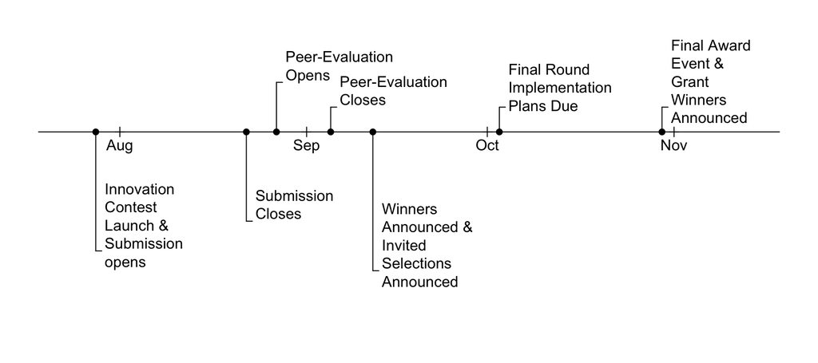

Timeline of the innovation contest

The innovation contest was divided into three main phases: the submission phase, the peer evaluation phase, and the implementation phase. The timing is shown in Figure .

In the four-week submission phase, all staff members were encouraged to identify one or more organizational problems and submit proposals addressing them. Employee participation was voluntary. All project submissions were done online via the website of the contest. There was no limit to the project proposals to submit (proposals could cover any issue within the organization, as described above), but each proposal was limited to approximately 300 words to lower the costs of entry and encourage broader participation. To ensure that treatment effects could be isolated, identified, and matched to participants, team submissions were not permitted. Limiting submissions to individual participation allowed us to match each submitter’s characteristics to the randomly assigned treatment. It also lowered incentives to communicate or exchange information with other employees. Also, the website was designed to not provide any information about the status of the contest during the submission period. In this way, decisions could not be easily influenced by the perceived popularity of the contest or previous submissions.

In the two-week peer evaluation phase, all staff members were invited to rate the merit and potential of submitted proposals on a five-point rating scale. All evaluations were done online on the website of the contest. Each signed-up employee was shown a list of anonymized proposals to read and rate. Proposals were presented at random in batches of 10 each. Each proposal was described by a title, a main description of the problem to solve, and the proposal. Voting was then introduced by the following text: “Rate this idea” followed by the rating scale: 1-low; 2; 3; 4; 5-high. Ratings were kept confidential and the website did not provide any feedback or any other kind of additional information that might have influenced individual judgment until the voting phase was over. Evaluators were free to decide how many (and which) proposals to rate. Since these were presented in a random order, every proposal had on average the same exposure to people asked to rate its quality. Evaluators were offered a limited edition T-shirt as a compensation for the effort in voting.

In the final implementation phase, employees having submitted proposals highly rated by peers and judged as particularly promising by the HTL staff were invited to submit a full proposal detailing plans for implementation. Following evaluation by MGH senior leadership, top proposals were selected to receive support and funding for implementation. This final phase took a few months to complete, essentially the time necessary to select and implement the best projects.

## The design

The basic idea of the experiment was to randomize the content of the communication announcing the innovation contest to all staff members. The start of the submission phase was indeed announced to everyone in a series of personalized emails. A direct message was sent to each contact in the list of employees’ emails from our subject pool.

The content of this communication with a placeholder for our treatment is reported below (a copy of the exact email is in the Appendix).

> Dear Heart Center team member,

> **Submit your ideas to [TREATMENT HERE]**

> The Ether Dome Challenge is your chance to submit ideas on how to improve the MGH Corrigan Minehan Heart Center, patient care and satisfaction, workplace efficiency and cost. All Heart Center Staff are eligible to submit ideas online. We encourage you to submit as many ideas as you have: no ideas are too big or too small!

> Submissions will be reviewed and judged in two rounds, first by the Heart Center staff via crowd-voting, and then by an expert panel. Winning ideas will be eligible for project implementation funding in the Fall of 2014!

A sample size of more than 300 units for each treatment ensured a sufficiently high statistical power based upon standard power calculations on the difference of proportions [@cohen1992power]. In testing the difference of proportions between any two treatments, the probability of type-I errors was slightly below $0.80$ for *small* differences at 5 percent significance level but higher than $0.80$ for *medium* and *large* differences at the more stringent 1 percent significance level.[^9]

Also, note the lack of a traditional “control” treatment in this study. Since the experiment was run in a workplace, we were constrained to carry out treatments having equal chances of being successful. This prevented us from having a ‘null’ treatment with no personalized incentives messaging as a control group. Indeed, the analysis focused on multiple comparisons of several unordered discrete treatments (e.g., prizes vs funding vs framing).[^10]

The MGH management and the HTL staff members were blind to group assignment, which prevented potential bias in the communication of the innovation contest that was not under our direct control. We also made an effort to create a “safe” environment for employees submitting proposals by making clear (in the application form) that the identity of the proponents was going to be kept private unless the employee self-identified, so that management could not identify workers without their consent.

Finally, we relied only on official channels for communication to strengthen the effect of the announcement and signal legitimacy of the contest. Each employee received the same exact solicitation email three times: at the launch, eight days from the launch and two days before the end of the submission phase of the challenge. Starting from the second week of the submission phase, information booths, flyers, and posters were used to encourage everyone to take part in the event and respond to the email solicitation. These flyers and posters were based on a generic, undifferentiated version of the solicitation email without the text of the treatments.

# Data

Our subject pool was the entire population working at the Heart Center as of the end of 2014, a total of 1,237 individuals. For each individual, we collected administrative data on the gender, the type of profession, and whether they had a fixed office location or not. Additional, complementary data were obtained for a limited group of 378 employees (31 percent). These extra data had self-reported information about employees’ demographics, such as age and years of tenure at the Heart Center, that were obtained from an online survey that was run about two months before the launch of the innovation contest.

# Results

## Submitting project proposals

We now turn our attention to the role of differences in the opportunity cost of participation (following Hypothesis H5 in Section ). Though staff may benefit from organizational improvements in similar ways, the opportunity cost of contributing time and effort to improvement will likely vary with the gender, profession, and organizational role of the employee. For example, the opportunity cost of time may reflect the sharp hourly wage differences by profession (e.g., physicians should face higher opportunity costs than other staff members). Differences in preferences between the genders can also have an impact on participation. For example, the willingness to volunteer effort for the benefit of others might be different between men and women. To study these hypotheses, we now model the conditional probability of submitting proposals as follows:

$$\begin{equation}
\label{eq: submit}
\Pr(\text{SUBMIT}_{ij})
= \alpha + \tau_{j} + \text{JOB}_{i} + \text{MALE}_{i} + \text{OFFICE}_{i},
\end{equation}$$

where the dependent variable $\text{SUBMIT}_{ij}$ is 1 if the employee $i$ in treatment $j$ has made a submission, and zero otherwise; the parameter $\tau_{j}$ denotes a change associated with the treatment $j$ controlling for the employee’s profession ($\text{JOB}_i$), the gender ($\text{MALE}_i$), and a dummy for office location ($\text{OFFICE}_i$) that indicates whether the employee had a permanent office instead of being assigned to a ward.[^12]

Viewing these results through our theoretical model, it appears that the contribution cost, $c$, may not change much between different categories of workers. This interpretation makes sense because everyone could have an idea on how to improve the organization, regardless of profession or background skills. Proposals were also required to be short and nontechnical in order to keep individual costs of participation small for everyone. On the other hand, the cost appears systematically lower for those with a fixed office; and one may speculate that these are employees higher up in the hierarchy with more experience of existing organizational problems and the available solutions and, therefore, lower costs for contributing project proposals.

### Interactions

We now turn to examine treatment interactions involving the employee’s gender and profession.[^15] Following extensive literature on differences in preferences between men and women [@croson2009gender], gender interactions might occur as a result of three main factors: differences in risk taking, social preferences (willingness to contribute to public goods), and competitive inclinations. If women prefer to work on activities that are less risky, more pro-social (e.g., aiming at improving people’s health) and where competition is less intense, then we should observe significant treatment interactions. Similarly, one may also expect treatment interactions associated with the employee’s profession since the information of a fixed-value prize (i.e., the PRIZE treatment) could be relatively less effective for employees with a higher income, such as doctors, than the others.

## Rating project proposals

One may find counterintuitive that there was less (although not significant) participation in the evaluation phase from employees in the PRIZE treatment than in the other treatments, given the greater participation in the submission phase. However, this result is not entirely surprising because only 70 percent of employees who made submissions resolved to rate proposals as well (we detect no difference in the propensity of submitting and rating proposals between the treatments); so, even a difference of 2 percentage points in submitting will shrink to about 1 percentage point in the rating phase. In other words, we were not expecting self-rating to affect evaluation much.

## The quality of the project proposals

The treatment interventions may not have only impacted the propensity to make a submission, but the quality of the submission as well. Of particular interest is any indication of a quantity versus quality trade-off. For example, if the FUND treatment which generated the fewest submissions also produced the highest quality submissions. A quality versus quantity trade-off would increase the complexity of choosing optimal incentives for employees.

One potential limit of assessing quality only on the basis of peer ratings is that the employees might have a different view of a proposal’s quality than executives (due, for instance, to a misalignment of incentives). Indeed, to ensure alignment between managerial goals and the peer assessment, all project proposals were further vetted by the HTL staff before being considered for implementation funding. So, we now focus on the outcomes of this vetting process to investigate more broadly the presence of treatment effects on the quality of project proposals.

The vetting process conducted by the HTL staff resulted in 93 proposals being scored (from 1 to 100 points) with the best 29 proposals invited to submit implementation plans. The remaining 20 proposals were excluded (and received a score of zero) either because flagged as inappropriate for funding or because the proponent manifested no intention to participate in the implementation phase (a Fisher’s Exact Test for Count Data finds no association between proposals excluded and treatments with a p-value of 0.652).

## The content of the project proposals

We also look at differences in the underlying complexity of the project proposal as captured by differences in the length (i.e., the word count) of a submission. Submissions were below 200 words in most cases with little differences between the treatments. Indeed, testing for a significant linear regression relationship between the length of submissions and treatment dummies returned an overall insignificant result (p=.43, F-test).

## Estimating social preferences

We assume the cost of making a submission $c$ is the same in each treatment,[^21] and the individual preferences are constant, being predetermined to our intervention. Then we derive a structural relationship between the observed difference in the probability of contributing $\Delta p$ and the difference in the expected rewards from winning $\Delta R$ between the treatments.That is,[^22]

$$\begin{equation}
\Delta p \approx\frac{\Delta R}{n (c - \gamma)}.
\end{equation}$$
(Throughout this section we will consider $\delta=0$ ignoring the distinction between impure and pure altruism.) By solving for $\gamma$, we get
$$\begin{equation}
\label{eq: gamma}
\gamma \approx c - \Delta R / (n\Delta p).
\end{equation}$$

# Discussion

We report results of a natural field experiment conducted at a medical organization that held an innovation contest seeking contribution of public goods (i.e., projects for organizational improvement) from its more than 1200 employees. The experiment tested incentives for contributing by manipulating the content of emails soliciting staff participation. We presented different incentives to participate in the contest, such as a prize (iPad mini) for winning submissions, improving patient care, improving the workplace, and funding for implementation. Each staff was randomly assigned to receiving an email containing one of the four incentives. Our data show that offering a prize for winning submissions boosted participation by 85 percent without affecting the quality of the submissions. The effect was consistent across gender and job type. We posit that the allure of a prize, in combination with mission-oriented preferences, drove participation. Using a simple model, we estimate that these preferences explain about a third of the magnitude of the effect.

These results were sensitive to the solicited person’s gender. Women’s participation was greater than men’s when email solicitations emphasized patient care, controlling for profession. One possible explanation for this finding is that female staff may be more altruistic and more responsive to the issue of improving patient care than male staff. However, the existing economic literature on gender differences in altruistic preferences [see @croson2009gender] does not fully support this explanation. Another possible reason for women’s greater responsiveness to patient care involves gender-based stereotypes, which are pervasive in health care organizations [@evans2002cautious]. Male staff could have judged the contribution of an innovation project towards patient care improvement as a female-typed activity. Similarly, @coffman2014evidence report that, in laboratory experiments, women were less likely to contribute ideas to groups when the topic falls in male-typed domains, e.g., sports, and vice versa.

An interesting non-finding is the lack of gender-based differences in the PRIZE treatment; we found that women’s participation was equal to men’s. An extensive literature in economics has revealed women’s tendency to be risk-averse [@borghans2009gender] and a distaste for competition [@niederle2007women], suggesting that a contest for prize may discourage women’s participation. In our experiment, however, women participated the most in the PRIZE treatment. We suspect that the unique characteristics of our subject pool (e.g., careers in health care) could have led to this finding.

While not observed, there could have been negative interactions between the prize incentive and the contest that encouraged staff members to contribute to public good by suggesting an organizational improvement opportunity. A negative interaction occurs when a particular incentive might crowd out the motive to contribute; for example, providing a self-serving incentive might negatively interact with a self-sacrificing activity and crowd out the motivation to participate in this activity. Experiments in the context of blood donations [@lacetera2013economic; @lacetera2014rewarding], or public “bads” in daycare pick-ups [@gneezy2000fine] indicate crowd-out effects. Pecuniary incentives may not have the same effect if in-kind gifts are used in place of currency [e.g., @kube2012currency], or if the setting already involves an employer-employee relationship [e.g, @fehr1998gift].

Ulterior motivations such as the prospect of a promotion [@baker1994internal; @gibbs1995incentive], professional prestige, or peer recognition [@kosfeld2011getting; @blanes2011tournaments] could have propelled participation. However, the likelihood of career advancement through participating in the contest seems marginal as promotions in academic hospitals are typically based on the number of publications, tenure, and professional training. In addition, our email solicitations contained incentives that are fairly neutral to potential career advancement opportunities associated with the contest. Recognition for authors of winning proposals included announcement during a hospital-wide public event and listing on the hospital website. These opportunities to be acknowledged equally affected all potential participants.

The Stable Unit Treatment Value Assumption (SUTVA) for causal inference [@rubin1974estimating] is relevant for all randomized experiments. In our study, it is possible that communication among staff assigned to different treatment arms could have influenced decisions to participate. The magnitude of the resulting effects would depend on the level of interference (i.e., intensity of staff communication) and the density of staff’ network of social interactions. Although this bias could severely distort our estimates, we expect the bias to cause differences in participation across treatments to converge to zero (a bias towards null effect) as communication spreads the content of the different email solicitations. Our findings exhibit little evidence of convergence. Communication among staff during the contest was likely limited as the Heart Center staff are scattered across multiple buildings on the hospital campus and competition provides weak incentives for information sharing.

Staffs’ poor understanding of the costs arising from winning the contest could explain their participation. In the same vein, a large experimental literature on contests [@dechenaux2014survey] shows that similar misconception could lead to higher effort levels than predicted. In particular, those in the PRIZE treatment could have underestimated the costs of participating as the iPad mini accentuated the appeal of an immediate reward and diminish the costs of winning the contest and becoming involved in implementation. Across treatments, however, we find that most of the staff submitted a detailed proposal on their project when invited to do so. Although participants might have had incorrect beliefs about expected costs from winning, these are unlikely to explain the significant differences.

Finally, while the choice of focusing on health care workers may limit the generalizability of our results in some respect, it should be noted that in the US alone health care spending accounts for 17 percent of the GDP (in 2015) and, more generally, our study results are also directly applicable to a variety of other professions exposed to a public good dilemma (e.g., teachers, public servants, researchers).

# Conclusions

Our results have implications that extend beyond the specific organization under study. Using a contest for prizes appears to be a more profitable way for firms to encourage contribution toward a public good among workers than currently acknowledged in the traditional tournament theory literature. The incentive effect of offering a prize for winning the contest interacts with pro-social motivations of workers to contribute to the public good.

# References